# Controlled Experiment on Different Mouse Pointer LocatingTechniques

# 1 Compare completion time among three settings

In this section, we test whether two visual enhancement techniques have significant impact to the completion time. ## Loading data Variable “start” represents starting position of mouse pointer.

```r
dataTime = read.csv(file = 'time.csv',  header = FALSE)
names(dataTime) = c('participant', 'start', 'target', 'tech', 'time')
```

## 1.1 Evaluation

Through a quick scan of the raw data, we find some outliers. May be some participants failed to find the target during tasks or they are distracted. Before evaluating the data, we exclude outliers and plot the raw data from 12 participants.

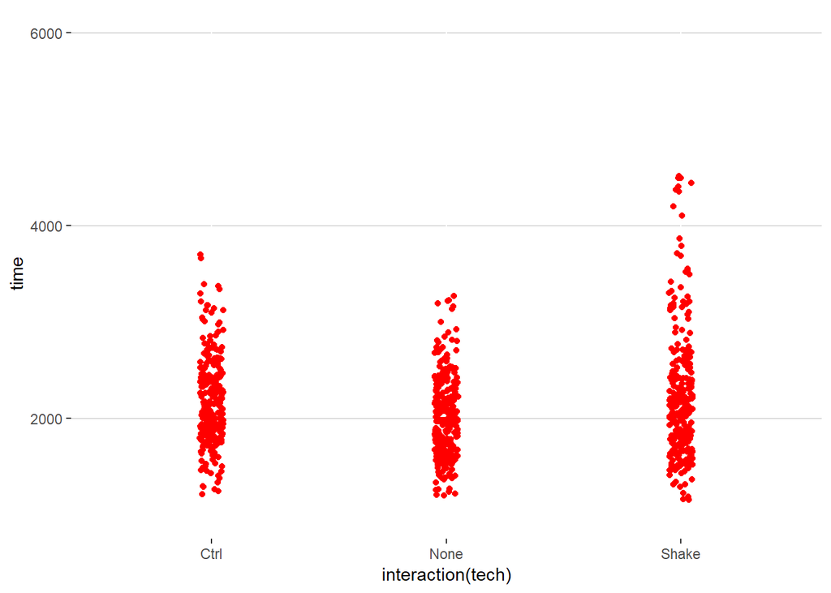

```r
dataTimeFilt = dataTime %>%
  group_by(tech) %>%
  filter(!abs(time - mean(time)) > 3 * sd(time))

ggplot() +
  geom_jitter(aes(interaction(tech), time), data = dataTimeFilt, colour = I("red"), position = position_jitter(width = 0.05)) +
  scale_y_continuous(limits = c(1000, 6000)) +
  theme(panel.background = element_blank(),
        panel.grid.major.y = element_line(size = .1, color = 'grey'))
```

## 1.2 Run ANOVA on movement time

```r
dataTimeAggr = dataTimeFilt %>%
  group_by(participant, tech) %>%
  summarise(time = mean(time))

# Convert the data using long format
dataTimeLong = melt(dataTimeAggr, id = c("participant", "tech", "time"))
```

Indicate the independent variables (visual enhancement techniques)

```r
dataTimeLong$tech = factor(dataTimeLong$tech)
```

Each participant uses all three techniques, we use repeated-measures ANOVA

```r
resultsTime = ezANOVA(dataTimeLong, dv=.(time), wid=.(participant), within=.(tech), detailed=TRUE)
kable(resultsTime$ANOVA)
```

[output not shown]

```r
kable(resultsTime$`Mauchly's Test for Sphericity`)
```

|  | Effect | W | p | p<.05 |
| --- | --- | --- | --- | --- |
| 2 | tech | 0.947599 | 0.7640521 |  |

```r
kable(resultsTime$`Sphericity Corrections`)
```

|  | Effect | GGe | p[GG] | p[GG]<.05 | HFe | p[HF] | p[HF]<.05 |
| --- | --- | --- | --- | --- | --- | --- | --- |
| 2 | tech | 0.9502081 | 0.1092605 |  | 1.143184 | 0.1059032 |  |

```r
kable(anova_apa(resultsTime, sph_corr ="gg", print=FALSE))
```

[output not shown]

```r
kable(ezStats(dataTimeLong, dv=.(time), wid=.(participant), within=.(tech)))
```

[output not shown]

# 2 Analyze whether visual enhancement has significant impact to distance ratio

The section we analyze the influnce of two techniques on $\tau$, which is the ratio between distance and displacement. ## Load data

```r
dataDist = read.csv('distance.csv', header=FALSE)
names = names(dataDist) = c('participant', 'start', 'target', 'tech', 'distanceRatio')
```

Similar to the previous analysis, we exclude outliers and plot raw data

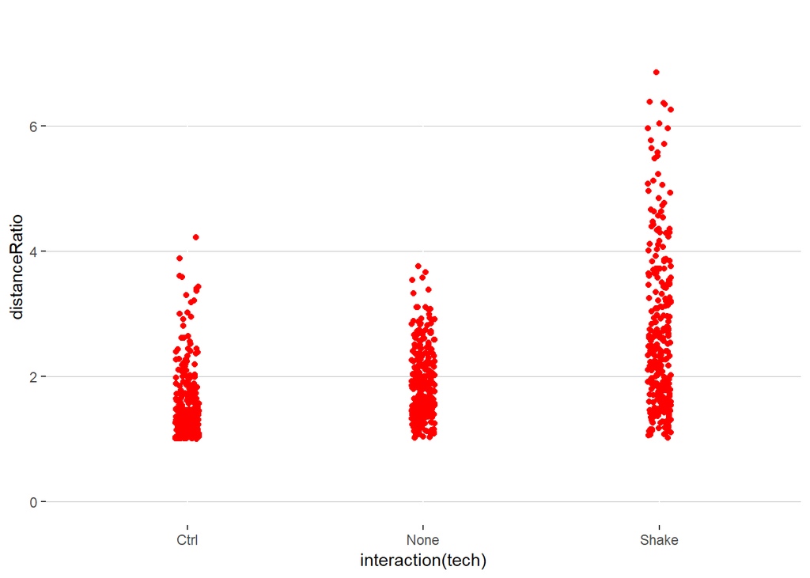

```r
dataDistFilt = dataDist %>%
  group_by(tech) %>%
  filter(!abs(distanceRatio - mean(distanceRatio)) > 3 * sd(distanceRatio))

ggplot() +
  geom_jitter(aes(interaction(tech), distanceRatio), data = dataDistFilt, colour = I("red"), position = position_jitter(width = 0.05)) +
  scale_y_continuous(limits = c(0,7.5)) +
  theme(panel.background = element_blank(),
        panel.grid.major.y = element_line(size = .1, color = 'grey'))
```

Then we aggregate the data and run ANOVA on distance ratio $\tau$

```r
dataDistAggr = dataDistFilt %>%
  group_by(participant, tech) %>%
  summarise(distanceRatio = mean(distanceRatio))

dataDistLong = melt(dataDistAggr, id = c("participant", "tech", "distanceRatio"))
dataDistLong$tech = factor(dataDistLong$tech)
resultsDist = ezANOVA(dataDistLong, dv=.(distanceRatio), wid=.(participant), within=.(tech), detailed=TRUE)
kable(resultsDist$ANOVA)
```

[output not shown]

```r
kable(resultsDist$`Mauchly's Test for Sphericity`)
```

|  | Effect | W | p | p<.05 |
| --- | --- | --- | --- | --- |
| 2 | tech | 0.4508384 | 0.0186253 | * |

```r
kable(resultsDist$`Sphericity Corrections`)
```

|  | Effect | GGe | p[GG] | p[GG]<.05 | HFe | p[HF] | p[HF]<.05 |
| --- | --- | --- | --- | --- | --- | --- | --- |
| 2 | tech | 0.6455104 | 0.0005727 | * | 0.6948336 | 0.0003912 | * |

```r
kable(anova_apa(resultsDist, sph_corr ="gg", print=FALSE))
```

[output not shown]

```r
kable(ezStats(dataDistLong, dv=.(distanceRatio), wid=.(participant), within=.(tech)))
```

[output not shown]

## 2.1 Pairwise comparisons

```r
attach(dataDistLong)
pw <- pairwise.t.test(distanceRatio, tech, p.adj = "bonferroni")
detach(dataDistLong)
kable(pw$p.value)
```

|  | Ctrl | None |
| --- | --- | --- |
| None | 0.5429567 | NA |
| Shake | 0.0001939 | 0.0089609 |

# 3 Plots presented in the report

This section shows figures in the report and our presentation

```r
library(Rmisc)
```

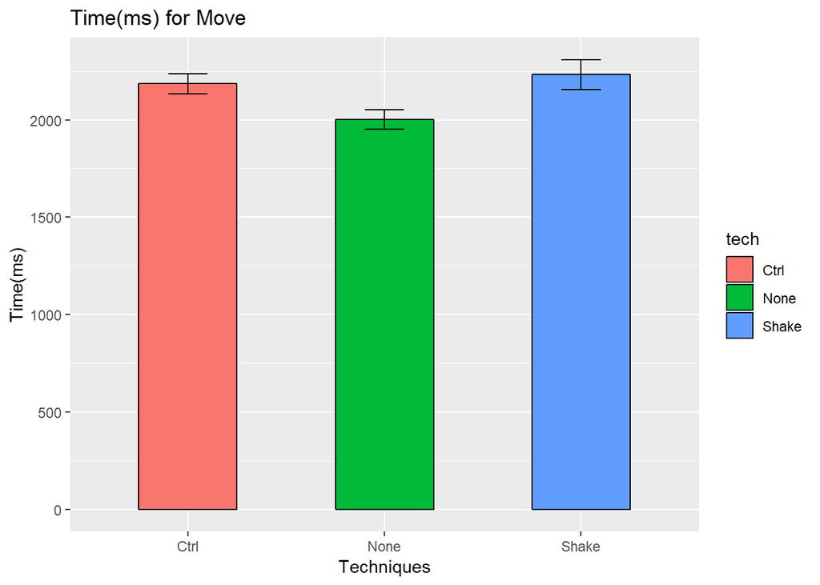

```r
dataTimeSummary = summarySE(dataTimeFilt, measurevar = 'time', groupvars = 'tech')

p = ggplot(dataTimeSummary, aes(x = tech, y = time, fill=tech)) +
  geom_bar(stat='identity', width=0.5, color="black", position=position_dodge()) +
  geom_errorbar(aes(ymin=time-ci, ymax=time+ci), width=.2, position=position_dodge()) +
  labs(title="Time(ms) for Move", x = "Techniques", y = "Time(ms)")
print(p)
```

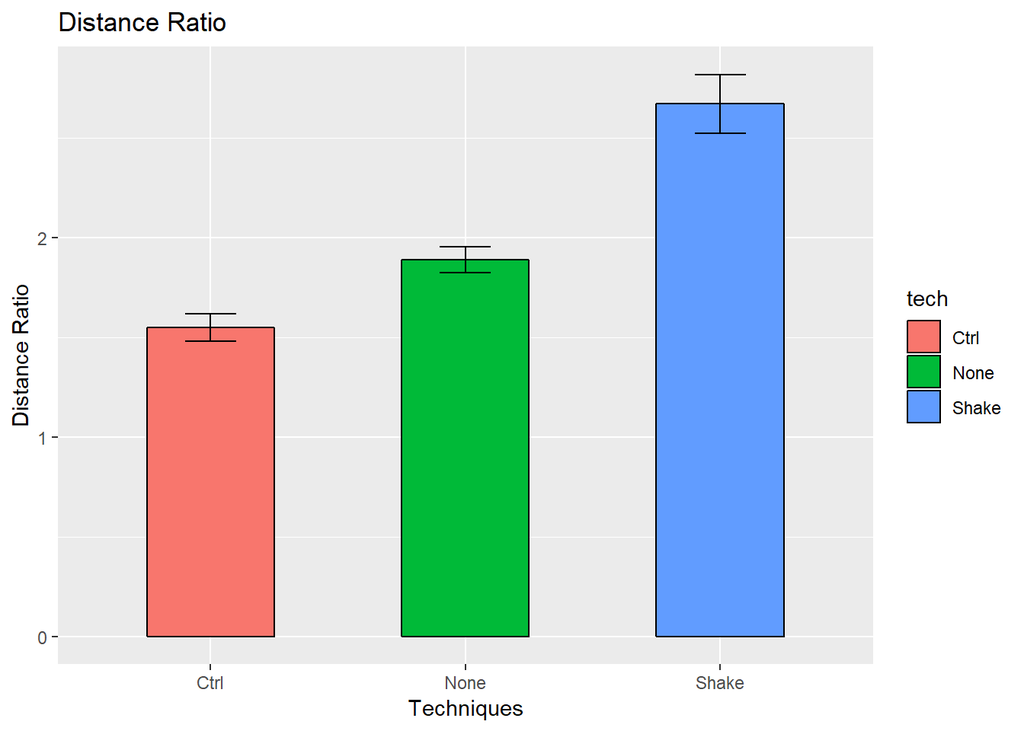

```r
# Don't run this before analysis is done, it will mask other function
library(Rmisc)
dataDistSummary = summarySE(dataDistFilt, measurevar = 'distanceRatio', groupvars = 'tech')
p = ggplot(dataDistSummary, aes(x = tech, y = distanceRatio, fill=tech)) +
  geom_bar(stat='identity', width=0.5, color="black", position=position_dodge()) +
  geom_errorbar(aes(ymin=distanceRatio-ci, ymax=distanceRatio+ci), width=.2, position=position_dodge()) +
  labs(title="Distance Ratio", x = "Techniques", y = "Distance Ratio")
print(p)
```